# Environmental Niche Factor Analysis - Species niche analysis and suitability maps

Gonzalo Albaladejo-Robles

31/07/2025

# Environmental Niche Factor Analysis (ENFA)

ENFA is a presence only method that analyze the multidimensional space form by the environmental information present in our study area of region of interest. The method compares the overall distribution of the multivariate space against that form only by the fraction of such space occupied by the species (presence data). Once both the shape of the environment and that of the species is define the centroid of the later one is defined. This niche centroid is then use to calculate the distance, in the multidimensional space, between the species niche and the rest of the environment. This is the Mahalanobis distance. Along with the distance of the environmental conditions to those of the species niche, other metrics are also calculated:

- Marginality: The difference between the mean environmental conditions of the species and the global mean.
- Specialization: The ratio of variance in the global environment to the variance in the species environment.

Base on this distance we can describe the overall level of species niche spatial cover, specialization, and overall habitat suitability.

### Run the analysis using the `ENFA_function`

#### a. Prepare the working environment

- Load some basic libraries for spatial data processing

```r
# 0. Load the needed packages needed ----
list.of.packages<-c("dplyr","sf","data.table","terra","tidyr","geodata","viridis")

new.packages <- list.of.packages[!(list.of.packages %in% installed.packages()[,"Package"])]
if(length(new.packages)) install.packages(new.packages)

lapply(list.of.packages,require,character.only=TRUE)
rm(list.of.packages,new.packages)
```

- Load the functions for the analysis

```r
# 0.1 Load the functions to run the analysis ----
  functions<-"./Functions" %>% list.files(recursive = FALSE,pattern = ".R$",full.names = TRUE)
  lapply(functions,function(x) source(x))
```

#### b. Load/Get the spatial data for the analysis

- Species records For this working example, we will use presence data for the European pine vole (*Microtus subterraneus*). We collected this data directly from [**GBIF**](https://www.gbif.org/) and can be found in the `Records` folder along with the data provided in this repository.

```r
# a. Species points----
  sf_use_s2(FALSE)
  Species_list <- list.files("./Data/Sp_info/Records",pattern = "Microtus subterraneus.csv",full.names = TRUE)

  # Load the CSV file with the records
  presence_dat <- Species_list %>% read.csv()

  # Transform the csv into an spatial object
  Sp_points <- presence_dat %>%   st_as_sf(coords=c("decimalLongitude","decimalLatitude"))
  Sp_points[,c(1:5)] %>% head()
```

```
## Simple feature collection with 6 features and 5 fields
## Geometry type: POINT
## Dimension:     XY
## Bounding box:  xmin: -2.17216 ymin: 46.16386 xmax: 7.63389 ymax: 48.90843
## CRS:           NA
##   X        key                                   scientificName
## 1 1 3121103233   Microtus subterraneus (Selys-Longchamps, 1836)
## 2 2  865732179   Microtus subterraneus (Selys-Longchamps, 1836)
## 3 3  865732125   Microtus subterraneus (Selys-Longchamps, 1836)
## 4 4 2488213815 Pitymys subterraneus (de Sélys-Longchamps, 1836)
## 5 5  865730369   Microtus subterraneus (Selys-Longchamps, 1836)
## 6 6  865730330   Microtus subterraneus (Selys-Longchamps, 1836)
##                      issues                           datasetKey
## 1                           aa5a1c3c-2fd1-40eb-9845-95b96dfb5bd2
## 2 cdc,gass84,colmano,inmafu 5a659248-1f70-11e3-b2c5-00145eb45e9a
## 3 cdc,gass84,colmano,inmafu 5a659248-1f70-11e3-b2c5-00145eb45e9a
## 4                       cdc e7c5a179-b6d7-497e-8fb9-41e0ef1bb21e
## 5 cdc,gass84,colmano,inmafu 5a659248-1f70-11e3-b2c5-00145eb45e9a
## 6 cdc,gass84,colmano,inmafu 5a659248-1f70-11e3-b2c5-00145eb45e9a
##                    geometry
## 1  POINT (7.60047 46.16386)
## 2  POINT (7.63389 46.18753)
## 3  POINT (6.85668 46.18619)
## 4  POINT (0.84543 48.90843)
## 5 POINT (-2.17216 48.02127)
## 6  POINT (7.37481 46.18768)
```

- Species ranges

  Species ranges, obtained from the (**IUCN Red List**)[https://www.iucnredlist.org/], are a good way to define the spatial extent of our study area, clean unwanted spatial records, and study the spatial niche of the target species

```r
# b. Species spatial information----
  IUCN_ranges <- "./Data/Sp_info/Ranges/Sp_ranges.shp" %>% st_read()
# b.1 Analysis study area----
  "./Data/Study_area" %>% dir.create(showWarnings = F,recursive = T)
  worldPol <- geodata::world(resolution = 5,path="./Data/Study_area") %>%   st_as_sf() %>% st_make_valid()
```

- Configure the study area:

  As with any species distribution model (SDM). Therefore, the distribution and size of our study area have an impact on the final results of the ENFA analysis. We are going to select countries that are in reach of our species’ range as our study area. To account for spatial bias in the delimitation of the IUCN range data, we will add a buffer of 100 km (~ 1 degree) around it.

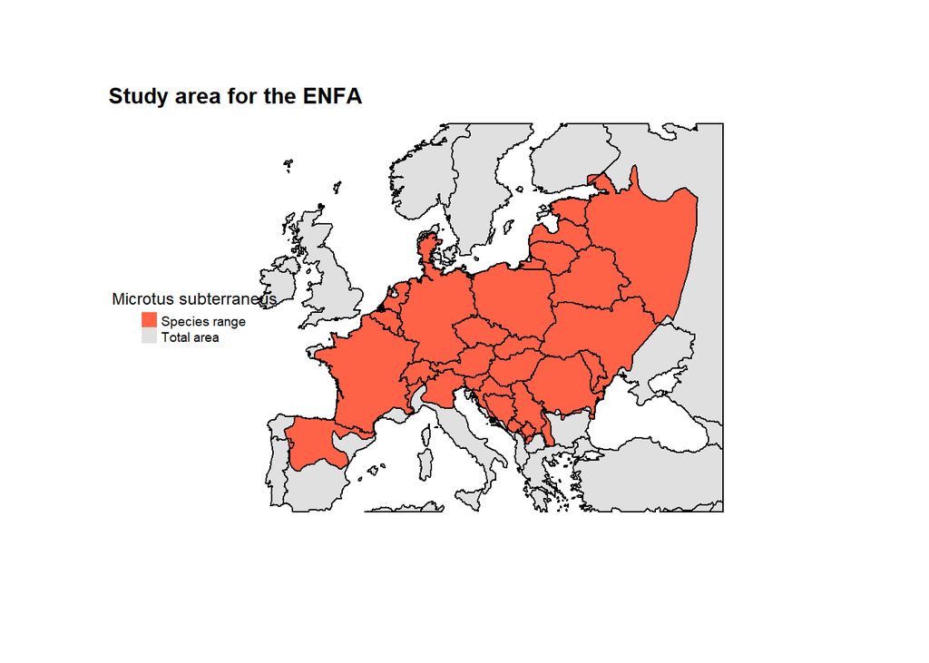

```r
plot(sty_area_united,col="grey88")
plot(IUCN_ranges %>% st_geometry(),col="tomato",add=T)
lines(sty_area)

legend("left",legend=c("Species range","Total area"),col=c("tomato","grey88"),pch=15,bty="n",title=Sp_points$species %>% unique(),title.cex = 0.75,cex=0.6,pt.cex = 1.5)
mtext(side=3,adj=0,"Study area for the ENFA",font=2)
```

- Load the environmental data We are going to download some climatic environmental data using the `geopackage` R-package data. For the modelling of the species niche we selected a set of 19 climatic environmental variables with biological potential. These are described in detail in [**WorldClim**](https://www.worldclim.org/data/bioclim.html).

```r
# c. Get the environmental information----
  "./Data/Env_vars" %>% dir.create(showWarnings = F,recursive = T)
  bio_w <- geodata::worldclim_global(var="bio",res=2.5,path=tempdir())
  writeRaster(bio_w,paste("./Data/Env_vars","wordClim.tif",sep="/"),overwrite=T)

  bio_w <- rast(paste("./Data/Env_vars","wordClim.tif",sep="/"))
  bio_sty <- crop(bio_w,sty_area %>% st_union() %>% vect())
```

- Clean the records

```r
# d. Remove points outside the IUCN range of the species----
  st_crs(Sp_points) <- st_crs(bio_w)
  Sp_points <- Sp_points %>% st_transform(crs=st_crs(bio_w))

  p_index <- st_intersects(Sp_points,IUCN_ranges %>% st_union(),sparse=F)
  Sp_points <- Sp_points[p_index,]
```

- Check the spatial data

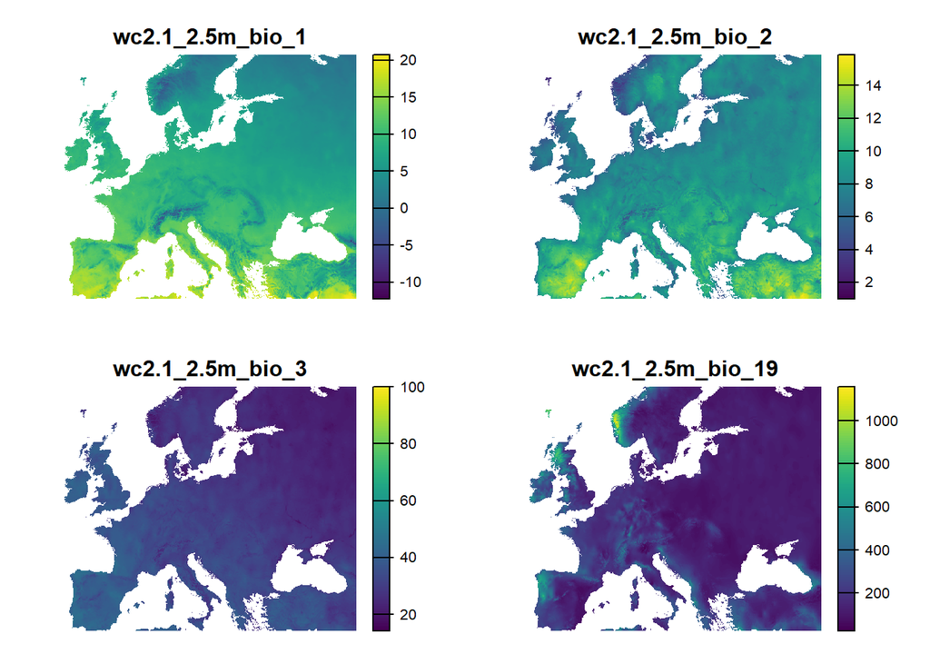

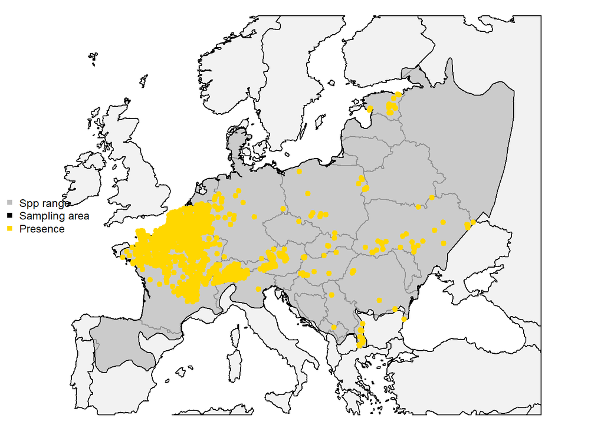

#### c. Extract the data for the presence data

For the analysis we need to indicate the algorithm which locations (pixels on the rasters) are occupied by the species and which other ones are going to form the environmental background. For this we are going to create a 0 (absence) and 1 (presence) index.

- Prepare a spatial index of presence points
- Prepare a spatial index of missing data

  Similar to the presence index, the `ENFA_function` does not accept `NA` values and also does not transform the results into spatial objects. For this reason, before removing the missing values from the environmental information we are going to map the location of it missing values. This index is going to use later on for the translation of the ENFA results into spatial data.

```r
  # Prepare environmental data
  env_dat <- bio_sty %>% terra::as.data.frame(na.rm=F)
  index_missing <- env_dat %>% complete.cases()

  env_dat <- env_dat[index_missing,]
  pres_index <- pres_index[index_missing]
```

#### d. Run the ENFA analysis

Using the `ENFA_function` we are going to perform the Environmental Niche Factor Analysis. This function runs a modified version of the code found in the [`ade4`](https://cran.r-project.org/web/packages/ade4/index.html) R-package. The original version of this function can be found (here)[https://cran.r-project.org/web/packages/ade4/index.html]. The main difference with the `ade4` function is that this functions does not rely on `dudi.pca` for the definition of variable and observations weights, this can be customize using the `col.weights` and `row.weights` arguments. Additionally, this function also returns the habitat suitability based on 1 - chi-square distribution applied to the Mahalanobis distance matrix. On top of this the `ENFA_function` returns:

1. `marginality`: the marginality values.
2. `row.weights` & `col.weights`: the observation and variable weights applied to the analysis. By default these are defined by: `rep(1, ncol(data))` & `rep(1, nrow(data))/nrow(data)` for columns and rows respectively.
3. `presence_index`: the cells in the spatial raster containing species presence information. e. `marginality_coordiantes`: the loading values of the different environmental variables on the marginality axis.
4. `coordinates_axis`: vector coordinates of the variables on the Marginality Specificity space. g. `marginality_specificity_vals`: Score values of the Marginality and Specificity axis
5. `niche_centroid_coordinates`: Coordinates on the specificity and Marginality space of the species niche centroid.
6. `prediction`: the Mahalanobis distance to the niche centroid of the environmental space. This distance is calculate over the Marginality and specificity space. By default this is define by the marginality axis (PC1 equivalent) and 2 specificity axis (PC2-3 equivalent).
7. `Suitability`: the values of habitat suitability calculated based on the Mahalanobis distance.

```r
  ENFA.r <- ENFA_function(data = env_dat,presence_index = pres_index)
```

- Check some of the function outputs

```r
# Niche centroid
ENFA.r$niche_centroid_coordinates
```

```
##     Marginality Specialization1 Specialization2
##    2.529552e+02    4.213515e-17   -2.351742e-15
```

```r
# Marginality values
head(ENFA.r$marginality_specificity_vals)
```

```
##     Marginality Specialization1 Specialization2
## 507    305.9351      -0.7828838     0.009538617
## 508    300.4265      -0.7144720     0.057382526
## 509    309.0254      -0.6857149     0.084362505
## 510    309.2906      -0.6418915     0.095462685
## 511    327.7756      -0.6587317     0.090371173
## 512    356.6196      -0.7182078     0.066818725
```

```r
# Axes coordinates
head(ENFA.r$coordinates_axis)
```

```
##                   Marginality Specialization1 Specialization2
## wc2.1_2.5m_bio_1  0.005348423     -0.05562928      0.57341906
## wc2.1_2.5m_bio_2 -0.003102672     -0.67749069     -0.14964819
## wc2.1_2.5m_bio_3  0.017479884      0.16544113      0.02725251
## wc2.1_2.5m_bio_4 -0.825450557     -0.01286096     -0.01229104
## wc2.1_2.5m_bio_5 -0.006626540      0.04349057      0.07317699
## wc2.1_2.5m_bio_6  0.019408492     -0.11279171      0.02774089
```

- Transform the results into spatial objects (rasters)

```r
# Transform the ENFA_results into rasters for the export
  empty_rast <- bio_sty$wc2.1_2.5m_bio_1 ; empty_rast[!is.na(empty_rast)] <- NA

# Get the different ENFA values
  # Mahalanobis distance
  maha <- empty_rast
  maha[index_missing] <- ENFA.r$prediction

  # Marginality
  Marginality <- empty_rast
  Marginality[index_missing] <- ENFA.r$marginality_specificity_vals$Marginality

  # Specialization
  Specialization <- empty_rast
  Specialization[index_missing] <- ENFA.r$marginality_specificity_vals$Specialization1

  # Suitability
  Suitability <- empty_rast
  Suitability[index_missing] <- ENFA.r$Suitability

  ENFA_rast <- c(maha,Marginality,Specialization, Suitability) ; names(ENFA_rast) <- c("Mahalanobis_dist","Marginality","Specificity", "Suitability")
```

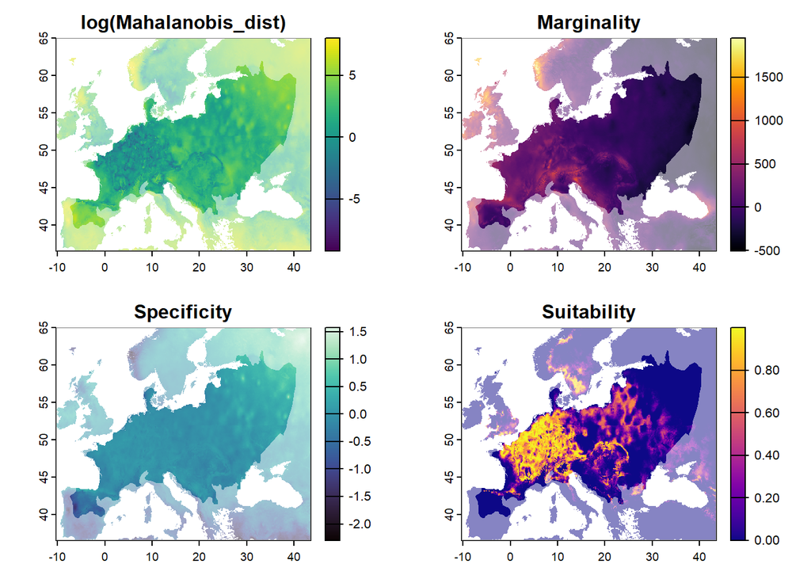

#### d. Retrive niche overlap and other ENFA related metrics

- Using the `plot_enfa` function we can extract niche overlap

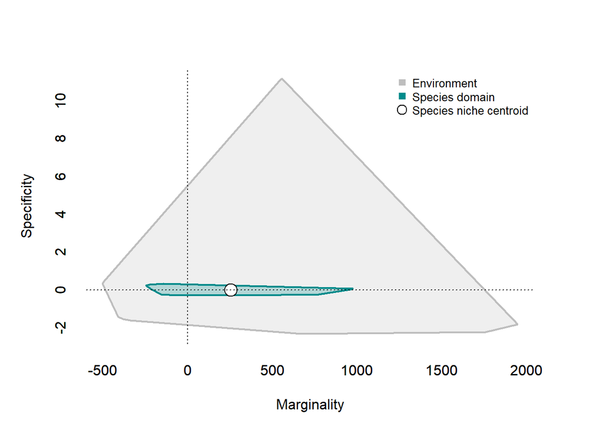

```r
# b. Get the rest of the ENFA parameters----
  par(mfrow=c(1,1))
  ENFA_extra<- plot_enfa(mar=ENFA.r$marginality_specificity_vals$Marginality, # Marginality vector
                       spc=ENFA.r$marginality_specificity_vals$Specialization1, # Specialization vector
                       m=ENFA.r$niche_centroid_coordinates, # Niche centroid
                       sp_rec=pres_index, # Species records index
                       plot_sp=T, # should we plot the results
                       pts=FALSE)
```

- Multyvariable space areas and niche overlap

```r
# Total area and niche area
ENFA_extra$areas
```

```
## Simple feature collection with 2 features and 3 fields
## Geometry type: POLYGON
## Dimension:     XY
## Bounding box:  xmin: -502.6936 ymin: -2.325684 xmax: 1947.581 ymax: 11.16789
## CRS:           NA
##   ID Type                       geometry       Area
## 1  1  Env POLYGON ((1937.446 -1.72043... 17671.9304
## 2  2  Spp POLYGON ((772.3709 -0.25211...   532.8195
```

```r
# % of niche overlap
ENFA_extra$prop.overlap
```

```
## [1] 3.015061
```

- Export the session information for this tutorial